# STAT 184 Final Project

```r
head(SerieA2015_2016_SeasonClean)
```

|  | Date | HomeTeam | AwayTeam | FullTimeHomeGoals | FullTimeAwayGoals | FullTimeResult | HalfTimeHomeGoals | HalfTimeAwayGoals | HalfTimeResult | HomeTeamShots | AwayTeamShots | HomeTeamShotsOnTarget | AwayTeamShotsOnTarget | HomeTeamFouls | AwayTeamFouls | HomeTeamCorners | AwayTeamCorners | HomeTeamYellowCards | AwayTeamYellowCards | HomeTeamRedCards | AwayTeamRedCards | FullTimeTotalGoals | HalfTimeTotalGoals | GoalDifferential | League | Matchup |
| --- | --- | --- | --- | --- | --- | --- | --- | --- | --- | --- | --- | --- | --- | --- | --- | --- | --- | --- | --- | --- | --- | --- | --- | --- | --- | --- |
| 1 | 2015-08-22 | Lazio | Bologna | 2 | 1 | H | 2 | 1 | H | 21 | 9 | 9 | 4 | 18 | 8 | 10 | 3 | 2 | 1 | 0 | 0 | 3 | 3 | 1 | Serie A | Lazio vs. Bologna |
| 2 | 2015-08-22 | Verona | Roma | 1 | 1 | D | 0 | 0 | D | 12 | 21 | 7 | 8 | 9 | 11 | 3 | 7 | 2 | 1 | 0 | 0 | 2 | 0 | 0 | Serie A | Verona vs. Roma |
| 3 | 2015-08-23 | Empoli | Chievo | 1 | 3 | A | 1 | 0 | H | 15 | 12 | 5 | 3 | 15 | 19 | 8 | 5 | 1 | 2 | 0 | 0 | 4 | 1 | -2 | Serie A | Empoli vs. Chievo |
| 4 | 2015-08-23 | Fiorentina | Milan | 2 | 0 | H | 1 | 0 | H | 13 | 8 | 7 | 0 | 18 | 16 | 4 | 5 | 3 | 2 | 0 | 1 | 2 | 1 | 2 | Serie A | Fiorentina vs. Milan |
| 5 | 2015-08-23 | Frosinone | Torino | 1 | 2 | A | 1 | 0 | H | 13 | 26 | 3 | 7 | 10 | 11 | 3 | 12 | 2 | 2 | 0 | 0 | 3 | 1 | -1 | Serie A | Frosinone vs. Torino |
| 6 | 2015-08-23 | Inter | Atalanta | 1 | 0 | H | 0 | 0 | D | 21 | 4 | 7 | 0 | 14 | 12 | 9 | 1 | 2 | 2 | 0 | 1 | 1 | 0 | 1 | Serie A | Inter vs. Atalanta |

```r
head(Datajoin)
```

|  | Date | HomeTeam | AwayTeam | FullTimeHomeGoals | FullTimeAwayGoals | FullTimeResult | HalfTimeHomeGoals | HalfTimeAwayGoals | HalfTimeResult | HomeTeamShots | AwayTeamShots | HomeTeamShotsOnTarget | AwayTeamShotsOnTarget | HomeTeamFouls | AwayTeamFouls | HomeTeamCorners | AwayTeamCorners | HomeTeamYellowCards | AwayTeamYellowCards | HomeTeamRedCards | AwayTeamRedCards | FullTimeTotalGoals | HalfTimeTotalGoals | GoalDifferential | League | Matchup | away.blocked.by.goalkeeper | away.coach | away.corners | … |
| --- | --- | --- | --- | --- | --- | --- | --- | --- | --- | --- | --- | --- | --- | --- | --- | --- | --- | --- | --- | --- | --- | --- | --- | --- | --- | --- | --- | --- | --- | --- |
| 1 | 2015-08-22 | Lazio | Bologna | 2 | 1 | H | 2 | 1 | H | 21 | 9 | 9 | 4 | 18 | 8 | 10 | 3 | 2 | 1 | 0 | 0 | 3 | 3 | 1 | Serie A | Lazio vs. Bologna | NA | Delio Rossi | NA | … |
| 2 | 2015-08-22 | Verona | Roma | 1 | 1 | D | 0 | 0 | D | 12 | 21 | 7 | 8 | 9 | 11 | 3 | 7 | 2 | 1 | 0 | 0 | 2 | 0 | 0 | Serie A | Verona vs. Roma | NA | Rudi Garcia | NA | … |
| 3 | 2015-08-23 | Empoli | Chievo | 1 | 3 | A | 1 | 0 | H | 15 | 12 | 5 | 3 | 15 | 19 | 8 | 5 | 1 | 2 | 0 | 0 | 4 | 1 | -2 | Serie A | Empoli vs. Chievo | NA | Rolando Maran | NA | … |
| 4 | 2015-08-23 | Fiorentina | Milan | 2 | 0 | H | 1 | 0 | H | 13 | 8 | 7 | 0 | 18 | 16 | 4 | 5 | 3 | 2 | 0 | 1 | 2 | 1 | 2 | Serie A | Fiorentina vs. Milan | NA | NA | NA | … |
| 5 | 2015-08-23 | Frosinone | Torino | 1 | 2 | A | 1 | 0 | H | 13 | 26 | 3 | 7 | 10 | 11 | 3 | 12 | 2 | 2 | 0 | 0 | 3 | 1 | -1 | Serie A | Frosinone vs. Torino | NA | Giampiero Ventura | NA | … |
| 6 | 2015-08-23 | Inter | Atalanta | 1 | 0 | H | 0 | 0 | D | 21 | 4 | 7 | 0 | 14 | 12 | 9 | 1 | 2 | 2 | 0 | 1 | 1 | 0 | 1 | Serie A | Inter vs. Atalanta | NA | Edoardo Reja | NA | … |

```r
head(DataSpread)
```

|  | gameday | home.coach | away.coach | HomeTeam | AwayTeam | FullorHalfTime | Goals |
| --- | --- | --- | --- | --- | --- | --- | --- |
| 1 | 1 | Stefano Pioli | Delio Rossi | Lazio | Bologna | FullTimeTotalGoals | 3 |
| 2 | 1 | Andrea Mandorlini | Rudi Garcia | Verona | Roma | FullTimeTotalGoals | 2 |
| 3 | 1 | Marco Giampaolo | Rolando Maran | Empoli | Chievo | FullTimeTotalGoals | 4 |
| 4 | NA | NA | NA | Fiorentina | Milan | FullTimeTotalGoals | 2 |
| 5 | 1 | Roberto Stellone | Giampiero Ventura | Frosinone | Torino | FullTimeTotalGoals | 3 |
| 6 | 1 | Roberto Mancini | Edoardo Reja | Inter | Atalanta | FullTimeTotalGoals | 1 |

- Since there is a home field effect, I will try to do most of my EDA on home team data only. If it shows a relationship for home data, it is likely that it will also show the same outcome for away match data.

```r
HomeGoalspergameData <- Datajoin%>%
  group_by(HomeTeam) %>%
  summarise(AvgGoalsperGame = mean(FullTimeTotalGoals))
head(HomeGoalspergameData)
```

| HomeTeam | AvgGoalsperGame |
| --- | --- |
| Atalanta | 2.526316 |
| Bologna | 2.157895 |
| Carpi | 2.578947 |
| Chievo | 2.263158 |
| Empoli | 2.210526 |
| Fiorentina | 2.631579 |

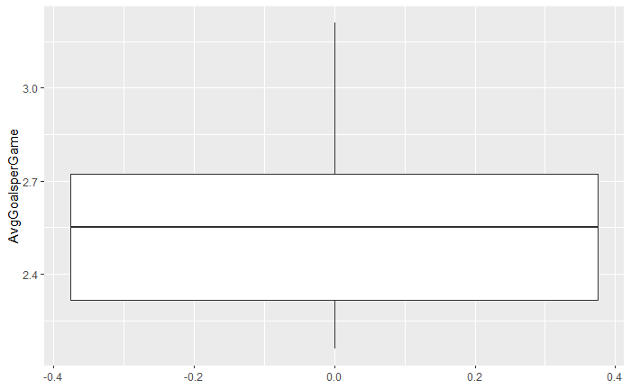

```r
# boxplot of average goals per game
ggplot(data=HomeGoalspergameData,aes(y=AvgGoalsperGame))+
  geom_boxplot()
```

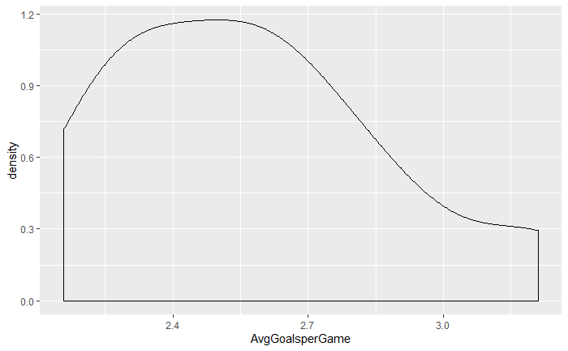

```r
# density plot of average goals per game
ggplot(data=HomeGoalspergameData,aes(x=AvgGoalsperGame))+
  geom_density()
```

- This boxplot and density plot show that there are a wide range of goals scored in a game, but the majority of them lie between 2.3 and 2.75 goals in a match on average.

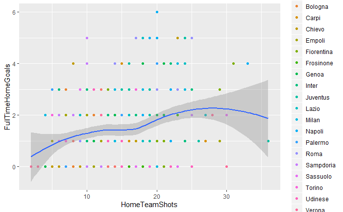

```r
# creating a plot that shows the relationship between shots on target and goals for the home team
ggplot(data=Datajoin,aes(x=HomeTeamShots,y=FullTimeHomeGoals))+
  geom_point(aes(color = HomeTeam)) +
  geom_smooth()
```

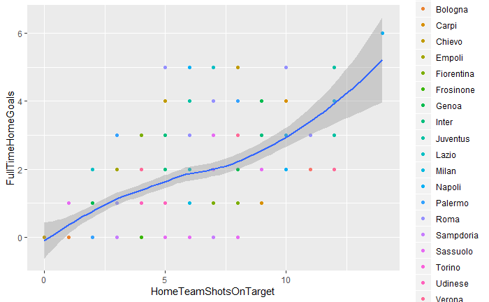

```r
ggplot(data=Datajoin,aes(x=HomeTeamShotsOnTarget,y=FullTimeHomeGoals))+
  geom_point(aes(color = HomeTeam)) +
  geom_smooth()
```

```r
#Creating a density plot for goal differential when teams play home seperated by result
HomeTeamPlot <- Datajoin %>%
  mutate(FullTimeResult = gsub(pattern = "A", replacement = "Loss", FullTimeResult),
         FullTimeResult = gsub(pattern = "D", replacement = "Draw", FullTimeResult),
         FullTimeResult = gsub(pattern = "H", replacement = "Win", FullTimeResult))
head(HomeTeamPlot)
```

|  | Date | HomeTeam | AwayTeam | FullTimeHomeGoals | FullTimeAwayGoals | FullTimeResult | HalfTimeHomeGoals | HalfTimeAwayGoals | HalfTimeResult | HomeTeamShots | AwayTeamShots | HomeTeamShotsOnTarget | AwayTeamShotsOnTarget | HomeTeamFouls | AwayTeamFouls | HomeTeamCorners | AwayTeamCorners | HomeTeamYellowCards | AwayTeamYellowCards | HomeTeamRedCards | AwayTeamRedCards | FullTimeTotalGoals | HalfTimeTotalGoals | GoalDifferential | League | Matchup | away.blocked.by.goalkeeper | away.coach | away.corners | … |
| --- | --- | --- | --- | --- | --- | --- | --- | --- | --- | --- | --- | --- | --- | --- | --- | --- | --- | --- | --- | --- | --- | --- | --- | --- | --- | --- | --- | --- | --- | --- |
| 1 | 2015-08-22 | Lazio | Bologna | 2 | 1 | Win | 2 | 1 | H | 21 | 9 | 9 | 4 | 18 | 8 | 10 | 3 | 2 | 1 | 0 | 0 | 3 | 3 | 1 | Serie A | Lazio vs. Bologna | NA | Delio Rossi | NA | … |
| 2 | 2015-08-22 | Verona | Roma | 1 | 1 | Draw | 0 | 0 | D | 12 | 21 | 7 | 8 | 9 | 11 | 3 | 7 | 2 | 1 | 0 | 0 | 2 | 0 | 0 | Serie A | Verona vs. Roma | NA | Rudi Garcia | NA | … |
| 3 | 2015-08-23 | Empoli | Chievo | 1 | 3 | Loss | 1 | 0 | H | 15 | 12 | 5 | 3 | 15 | 19 | 8 | 5 | 1 | 2 | 0 | 0 | 4 | 1 | -2 | Serie A | Empoli vs. Chievo | NA | Rolando Maran | NA | … |
| 4 | 2015-08-23 | Fiorentina | Milan | 2 | 0 | Win | 1 | 0 | H | 13 | 8 | 7 | 0 | 18 | 16 | 4 | 5 | 3 | 2 | 0 | 1 | 2 | 1 | 2 | Serie A | Fiorentina vs. Milan | NA | NA | NA | … |
| 5 | 2015-08-23 | Frosinone | Torino | 1 | 2 | Loss | 1 | 0 | H | 13 | 26 | 3 | 7 | 10 | 11 | 3 | 12 | 2 | 2 | 0 | 0 | 3 | 1 | -1 | Serie A | Frosinone vs. Torino | NA | Giampiero Ventura | NA | … |
| 6 | 2015-08-23 | Inter | Atalanta | 1 | 0 | Win | 0 | 0 | D | 21 | 4 | 7 | 0 | 14 | 12 | 9 | 1 | 2 | 2 | 0 | 1 | 1 | 0 | 1 | Serie A | Inter vs. Atalanta | NA | Edoardo Reja | NA | … |

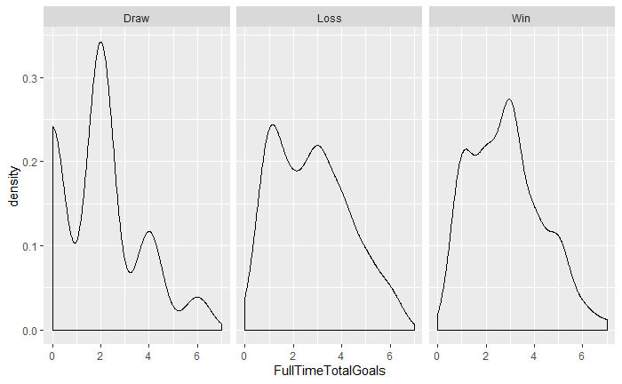

```r
ggplot(data=HomeTeamPlot, aes(x=FullTimeTotalGoals))+
  geom_density() +
  facet_wrap(~FullTimeResult)
```

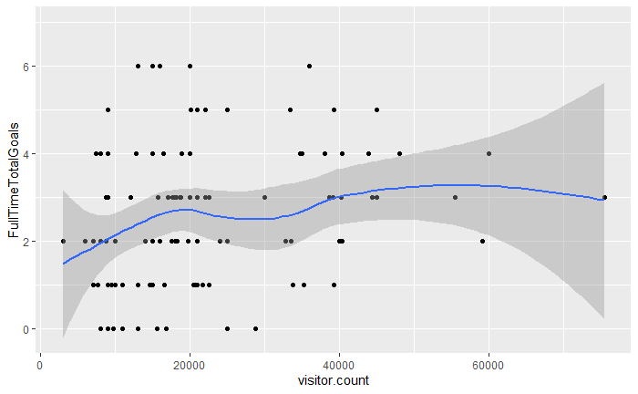

```r
# creating a plot of crowd size vs goals in a match
ggplot(data=Datajoin, aes(x=visitor.count,y=FullTimeTotalGoals))+
  geom_point()+
  geom_smooth()
```

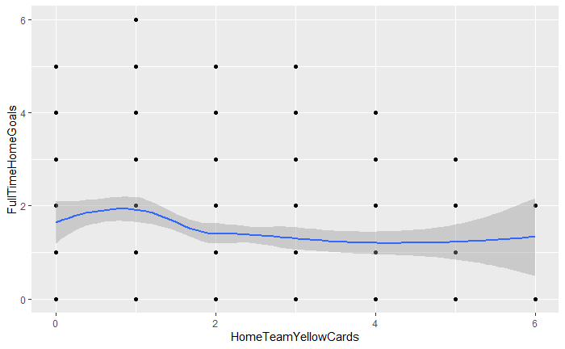

```r
# Creating a plot that shows amount of yellow cards vs goals scored for the home team
ggplot(data = Datajoin, aes(x=HomeTeamYellowCards,y=FullTimeHomeGoals))+
  geom_point()+
  geom_smooth()
```

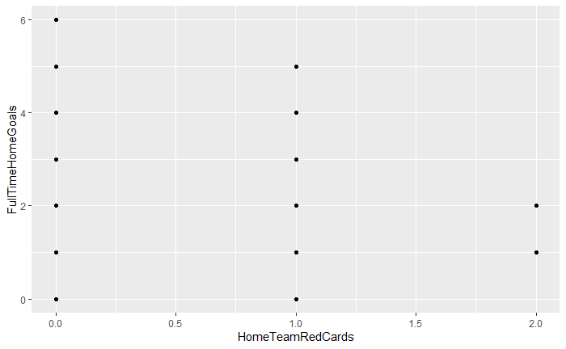

```r
# Create another plot that shows red cards vs goals scored for the home team
ggplot(data = Datajoin, aes(x=HomeTeamRedCards,y=FullTimeHomeGoals))+
  geom_point()+
  geom_smooth()
```

- Yellow cards don’t seem to have any significant effect on goals scored, but it seems there may be a small effect from yellow cards
- There are not many points for this, since not many games have red cards let alone more than one. But, there still does seem to be a negative relationship, the more red cards a team gets the less goals they will score.